# Final Assignment

#### **1.5 The graphical overview of correlations with the advanced corrplot() function**

Here’s the visualization of the correlation matrix with the advanced *corrplot()* function. To reduce repetition, we’ll visualize only the upper part of the plot (as is well known, the top part of the correlation matrix contains the same correlations as the bottom part)

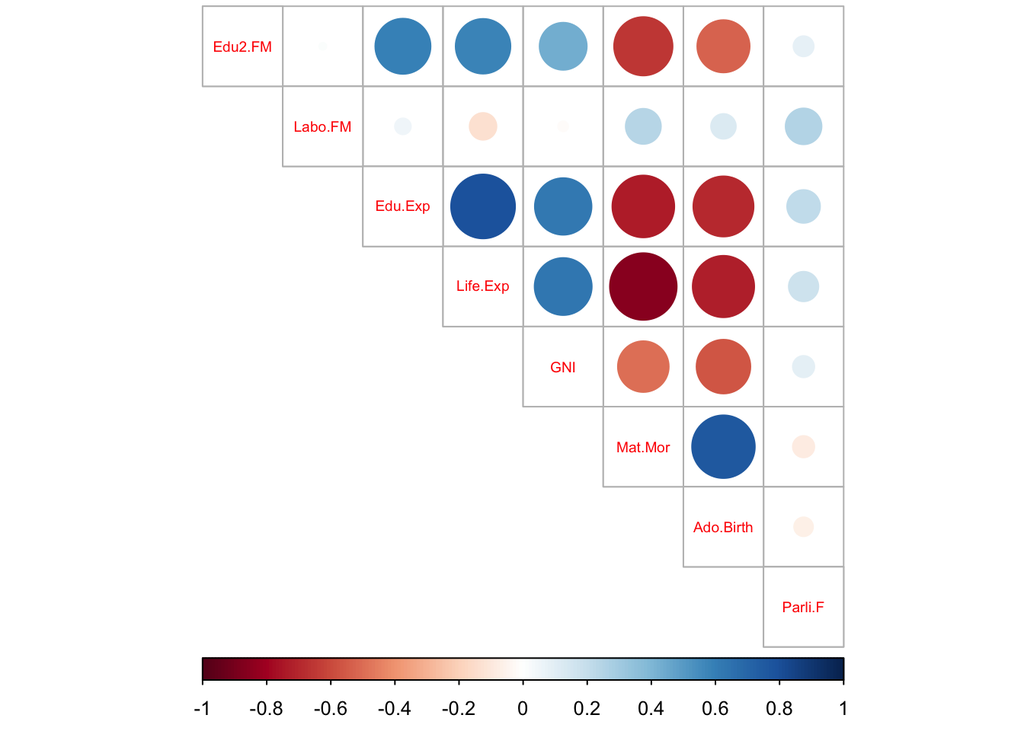

#### **1.6 The above summaries and visualizations showed the following**

**Here are some of the exposed correlations**

- Strong positive correlations between the following variable pairs
  - Edu.Exp : Life.Exp
  - Mat.Mor : Ado.Birth
- Moderate positive correlation between the following variable pairs
  - Edu.Exp : Edu2.FM
  - Life.Exp : Edu2.FM
  - Life.Exp : GNI
  - GNI : EduExp
- Strong negative correlation between the following variable pairs
  - Life.Exp : Mat.Mor
  - Mat.Mor : Edu.Exp
- Moderate negative correlation between the following variable pairs
  - Ado.Birth : Edu2.FM
  - GNI: Ado.Birth
- Minimal or zero correlation between the following variable pairs
  - GNI : Labo.FM
  - GNI : Parli.FM
  - Parli.FM : Edu2.FM
  - Labo.FM : Edu.Exp

### **2. Performing the Principal component analysis (PCA) on the human data**

#### **2.1 PCA on non-standardized data**

Next we’ll perform principal component analysis (PCA) on the not standardized human data and show variability captured by the principal components.

```
## PC1 PC2 PC3 PC4 PC5 PC6 PC7 PC8
## 100   0   0   0   0   0   0   0
```

Then we’ll draw a biplot displaying the observations by the first two principal components (PC1 coordinate in x-axis, PC2 coordinate in y-axis), along with arrows representing the original variables. (0-2 points)

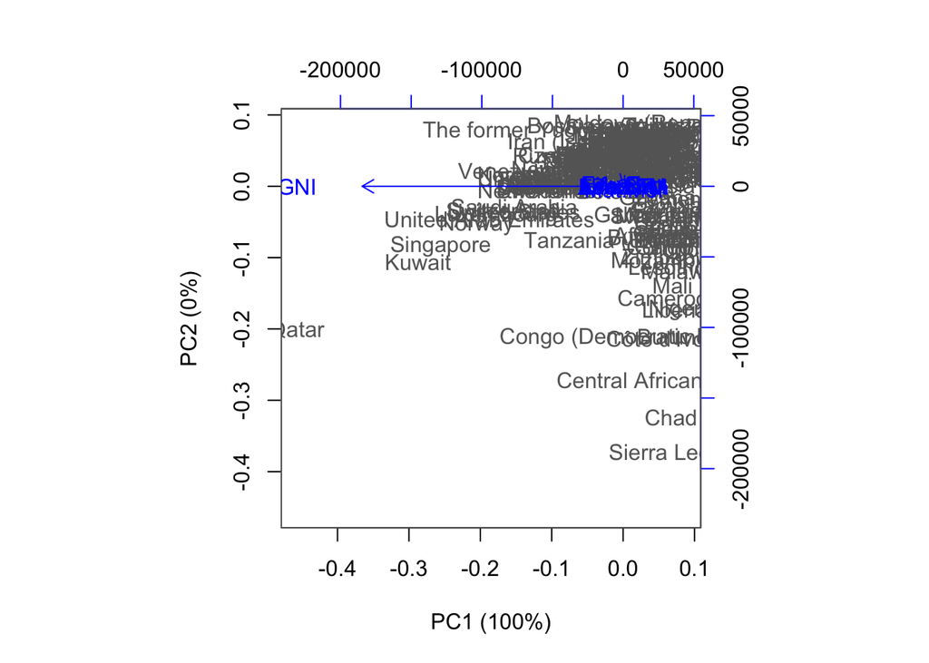

There’s something wrong with this PCA and it’s plot. The first principal (PC1) component explain 100% of the variance and the following principal components (PC2-PC8) explain 0 %. The only variable name shown is GNI which is connected to the first principal component. PCA is sensitive to the relative scaling of the original features and assumes that features with larger variance are more important than features with smaller variance. The human dataset’s GNI variable has a radically bigger scale and thus bigger variance than other variables (the long arrow also tells us there’s a quite big stadard variation within this variable). This is why this PCA with non-standardized variables failed miserably.

Let’s fix this problem by standardizing the data before using it in the principal component analysis.

#### **2.2 PCA on standardized/scaled data**

Here are the summaries of the scaled variables. See how the variables changed ( e.g. the means are now all at zero). As we can see below, the distribution of explainability is now more spread among the PC’s. The PCA plot also makes now a lot more sense.

```
##     Edu2.FM           Labo.FM           Edu.Exp           Life.Exp
##  Min.   :-2.8189   Min.   :-2.6247   Min.   :-2.7378   Min.   :-2.7188
##  1st Qu.:-0.5233   1st Qu.:-0.5484   1st Qu.:-0.6782   1st Qu.:-0.6425
##  Median : 0.3503   Median : 0.2316   Median : 0.1140   Median : 0.3056
##  Mean   : 0.0000   Mean   : 0.0000   Mean   : 0.0000   Mean   : 0.0000
##  3rd Qu.: 0.5958   3rd Qu.: 0.7350   3rd Qu.: 0.7126   3rd Qu.: 0.6717
##  Max.   : 2.6646   Max.   : 1.6632   Max.   : 2.4730   Max.   : 1.4218
##       GNI             Mat.Mor          Ado.Birth          Parli.F
##  Min.   :-0.9193   Min.   :-0.6992   Min.   :-1.1325   Min.   :-1.8203
##  1st Qu.:-0.7243   1st Qu.:-0.6496   1st Qu.:-0.8394   1st Qu.:-0.7409
##  Median :-0.3013   Median :-0.4726   Median :-0.3298   Median :-0.1403
##  Mean   : 0.0000   Mean   : 0.0000   Mean   : 0.0000   Mean   : 0.0000
##  3rd Qu.: 0.3712   3rd Qu.: 0.1932   3rd Qu.: 0.6030   3rd Qu.: 0.6127
##  Max.   : 5.6890   Max.   : 4.4899   Max.   : 3.8344   Max.   : 3.1850
```

```
##  PC1  PC2  PC3  PC4  PC5  PC6  PC7  PC8
## 53.6 16.2  9.6  7.6  5.5  3.6  2.6  1.3
```

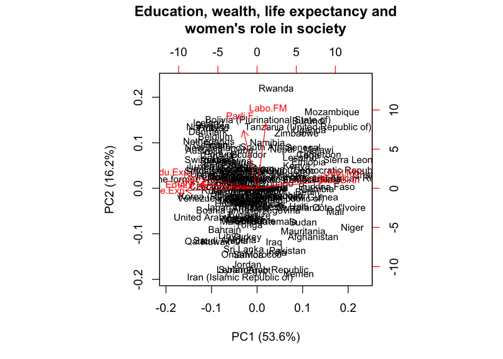

**Let’s take a closer look at the countries on the “west side” of the biplot and close to PC2.**

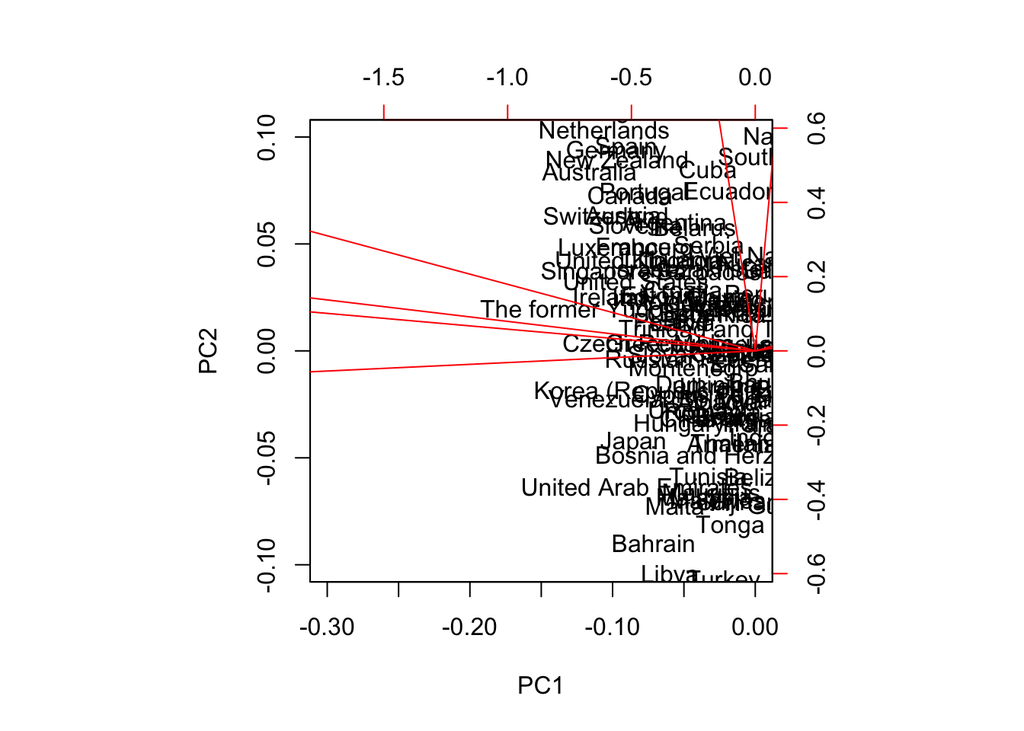

#### **2.3 Intepretation and analysis of PCA and the corresponding biplots**

Let’s interpret the results of both analysis and their corresponding biblots The biplot that was plotted from the non-standardized data (the one with the blue arrow) was not very informative, as we learnt above. The second biplot based on the standardized variables on the contrary offers a lot of interesting and visible information.

**Intepretation of PC1**

Generally speaking, the 1st principal component captures the maximum amount of variance from the features in the original data. Here the amount of variance of the data captured by PC1 is 53.6 %. The variables/features connected to the PC1 dimension are Mat.Mor (maternal mortality) and Ado.Birth (adolescent birth) pointing their arrows horizontally to the right and Edu.Exp, Life.Exp, Edu2.FM and GNI pointing their arrows horizontally to the left (Mat.Mor and Ado.Birth have a strong negative correlation with Edu.Exp, Life.Exp, Edu2.FM and GNI, as I explained above). The countries on the right end of the PC1’s horizontal axis are mostly poor African countries with low education connected variable values and on the opposite side (left) rich European and Asian countries (+ the USA) with high education connected variable values.

**Intepretation of PC2**

The 2nd principal component PC2 is orthogonal to the first and it captures the maximum amount of variability/variance left. Here that amount is 16.2 %. PC2 describes how actively women take part in the political sphere and the working life of the society they live in. Many Arab states are located at the low end of the vertical PC2 axis shown in the plot.

### **3. Performing the Multiple Correspondence Analysis (MCA) on the tea data**

Next we’ll load the tea dataset from the package Factominer and explore the data briefly.

#### **3.1 The structure and dimensions of the data**

Let’s look at the structure and the dimensions of the data first. Then we’ll create a subset of it by selecting the following variables.

- Sport
- effect.on.health
- sophisticated
- spirituality
- friends
- sex

```
## [1] "Sport"            "effect.on.health" "sophisticated"
## [4] "spirituality"     "friends"          "sex"
```

```
## [1] 300  36
```

```
## 'data.frame':    300 obs. of  36 variables:
##  $ breakfast       : Factor w/ 2 levels "breakfast","Not.breakfast": 1 1 2 2 1 2 1 2 1 1 ...
##  $ tea.time        : Factor w/ 2 levels "Not.tea time",..: 1 1 2 1 1 1 2 2 2 1 ...
##  $ evening         : Factor w/ 2 levels "evening","Not.evening": 2 2 1 2 1 2 2 1 2 1 ...
##  $ lunch           : Factor w/ 2 levels "lunch","Not.lunch": 2 2 2 2 2 2 2 2 2 2 ...
##  $ dinner          : Factor w/ 2 levels "dinner","Not.dinner": 2 2 1 1 2 1 2 2 2 2 ...
##  $ always          : Factor w/ 2 levels "always","Not.always": 2 2 2 2 1 2 2 2 2 2 ...
##  $ home            : Factor w/ 2 levels "home","Not.home": 1 1 1 1 1 1 1 1 1 1 ...
##  $ work            : Factor w/ 2 levels "Not.work","work": 1 1 2 1 1 1 1 1 1 1 ...
##  $ tearoom         : Factor w/ 2 levels "Not.tearoom",..: 1 1 1 1 1 1 1 1 1 2 ...
##  $ friends         : Factor w/ 2 levels "friends","Not.friends": 2 2 1 2 2 2 1 2 2 2 ...
##  $ resto           : Factor w/ 2 levels "Not.resto","resto": 1 1 2 1 1 1 1 1 1 1 ...
##  $ pub             : Factor w/ 2 levels "Not.pub","pub": 1 1 1 1 1 1 1 1 1 1 ...
##  $ Tea             : Factor w/ 3 levels "black","Earl Grey",..: 1 1 2 2 2 2 2 1 2 1 ...
##  $ How             : Factor w/ 4 levels "alone","lemon",..: 1 3 1 1 1 1 1 3 3 1 ...
```

[output cut: 22 more lines]

```
##  [1] "breakfast"        "tea.time"         "evening"
##  [4] "lunch"            "dinner"           "always"
##  [7] "home"             "work"             "tearoom"
## [10] "friends"          "resto"            "pub"
## [13] "Tea"              "How"              "sugar"
## [16] "how"              "where"            "price"
## [19] "age"              "sex"              "SPC"
## [22] "Sport"            "age_Q"            "frequency"
## [25] "escape.exoticism" "spirituality"     "healthy"
## [28] "diuretic"         "friendliness"     "iron.absorption"
## [31] "feminine"         "sophisticated"    "slimming"
## [34] "exciting"         "relaxing"         "effect.on.health"
```

#### **3.2 The structure and the summary of the subsetted data**

```
## 'data.frame':    300 obs. of  6 variables:
##  $ Sport           : Factor w/ 2 levels "Not.sportsman",..: 2 2 2 1 2 2 2 2 2 1 ...
##  $ effect.on.health: Factor w/ 2 levels "effect on health",..: 2 2 2 2 2 2 2 2 2 2 ...
##  $ sophisticated   : Factor w/ 2 levels "Not.sophisticated",..: 1 1 1 2 1 1 1 2 2 1 ...
##  $ spirituality    : Factor w/ 2 levels "Not.spirituality",..: 1 1 1 2 2 1 1 1 1 1 ...
##  $ friends         : Factor w/ 2 levels "friends","Not.friends": 2 2 1 2 2 2 1 2 2 2 ...
##  $ sex             : Factor w/ 2 levels "F","M": 2 1 1 2 2 2 2 1 2 2 ...
```

```
##            Sport                effect.on.health           sophisticated
##  Not.sportsman:121   effect on health   : 66     Not.sophisticated: 85
##  sportsman    :179   No.effect on health:234     sophisticated    :215
##            spirituality        friends    sex
##  Not.spirituality:206   friends    :196   F:178
##  spirituality    : 94   Not.friends:104   M:122
```

#### **3.3 The visual overview of the data**

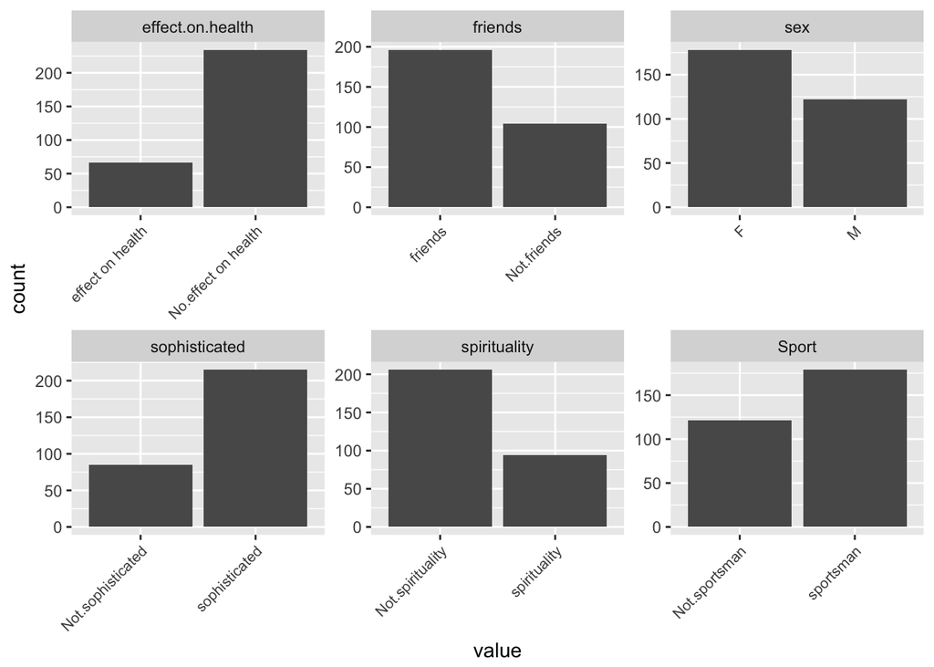

#### **3.4 Performing the Multiple Correspondence analysis on the data**

Let’s do the multiple correspondence analysis of selected tea variables.

```
##
## Call:
## MCA(X = tea_time, graph = FALSE)
##
##
## Eigenvalues
##                        Dim.1   Dim.2   Dim.3   Dim.4   Dim.5   Dim.6
## Variance               0.225   0.175   0.169   0.159   0.140   0.132
## % of var.             22.474  17.492  16.890  15.938  14.029  13.176
## Cumulative % of var.  22.474  39.967  56.857  72.795  86.824 100.000
##
## Individuals (the 10 first)
##                        Dim.1    ctr   cos2    Dim.2    ctr   cos2    Dim.3
## 1                   |  0.941  1.315  0.730 |  0.294  0.165  0.071 | -0.407
## 2                   |  0.561  0.468  0.290 | -0.123  0.029  0.014 | -0.554
## 3                   |  0.389  0.225  0.176 | -0.691  0.909  0.555 | -0.367
## 4                   | -0.333  0.165  0.087 |  1.007  1.933  0.791 | -0.108
## 5                   |  0.599  0.532  0.239 |  0.722  0.993  0.347 | -0.402
## 6                   |  0.941  1.315  0.730 |  0.294  0.165  0.071 | -0.407
## 7                   |  0.769  0.878  0.599 | -0.273  0.142  0.076 | -0.220
## 8                   |  0.069  0.007  0.007 |  0.119  0.027  0.019 | -0.392
## 9                   |  0.449  0.300  0.235 |  0.536  0.548  0.335 | -0.245
## 10                  |  0.501  0.373  0.186 |  0.337  0.216  0.084 | -0.274
##                        ctr   cos2
## 1                    0.326  0.136 |
## 2                    0.605  0.282 |
## 3                    0.266  0.157 |
## 4                    0.023  0.009 |
## 5                    0.318  0.107 |
## 6                    0.326  0.136 |
## 7                    0.095  0.049 |
## 8                    0.304  0.211 |
## 9                    0.119  0.070 |
## 10                   0.149  0.056 |
##
## Categories (the 10 first)
##                         Dim.1     ctr    cos2  v.test     Dim.2     ctr
## Not.sportsman       |  -0.747  16.695   0.377 -10.621 |   0.064   0.158
## sportsman           |   0.505  11.285   0.377  10.621 |  -0.043   0.107
## effect on health    |   0.342   1.912   0.033   3.143 |  -0.007   0.001
```

[output cut: 12 more lines]

```
## Not.sophisticated     0.075  -4.739 |  -0.285   2.271   0.032  -3.099 |
## sophisticated         0.075   4.739 |   0.113   0.898   0.032   3.099 |
## Not.spirituality      0.248  -8.612 |  -0.004   0.001   0.000  -0.096 |
## spirituality          0.248   8.612 |   0.008   0.002   0.000   0.096 |
## friends               0.459 -11.716 |   0.160   1.640   0.048   3.787 |
## Not.friends           0.459  11.716 |  -0.301   3.092   0.048  -3.787 |
##
## Categorical variables (eta2)
##                       Dim.1 Dim.2 Dim.3
## Sport               | 0.377 0.003 0.026 |
## effect.on.health    | 0.033 0.000 0.876 |
## sophisticated       | 0.398 0.075 0.032 |
## spirituality        | 0.204 0.248 0.000 |
## friends             | 0.054 0.459 0.048 |
## sex                 | 0.282 0.265 0.032 |
```

#### **3.5 Analyzing the MCA’s summary table**

- The eigen values show the amount of variance captured by the different dimensions. Here we can see the following.
  - Dimension 1 captures 22.5 % of the variance within the data
  - Dimension 2 captures 17.5 % of the variance within the data *The first two dimensions capture approximately 40 % of the variance within the data. This amount is considerably lower than the amount captured by the first two principal components in the previous analysis of the human dataset.
- The individuals
  - the individuals coordinates, the individuals contribution (%) on the dimension and the cos2 (the squared correlations) on the dimensions.
- The categories
  - The Categories part shows coordinates of the variable categories, the contribution (%), the cos2 (the squared correlations) and v.test value.
- The Categorical value
  - Shows the squared correlation between each variable and the dimensions
  - If the value is close to one it indicates a strong link with the variable and dimension. Here (among the three dimensions shown), only Dimension 3 and and the effect.on.health have a categorical variable that is close to one (0.876)

#### **3.6 Visualizing the Multiple Correspondence Analysis with the plot() function**

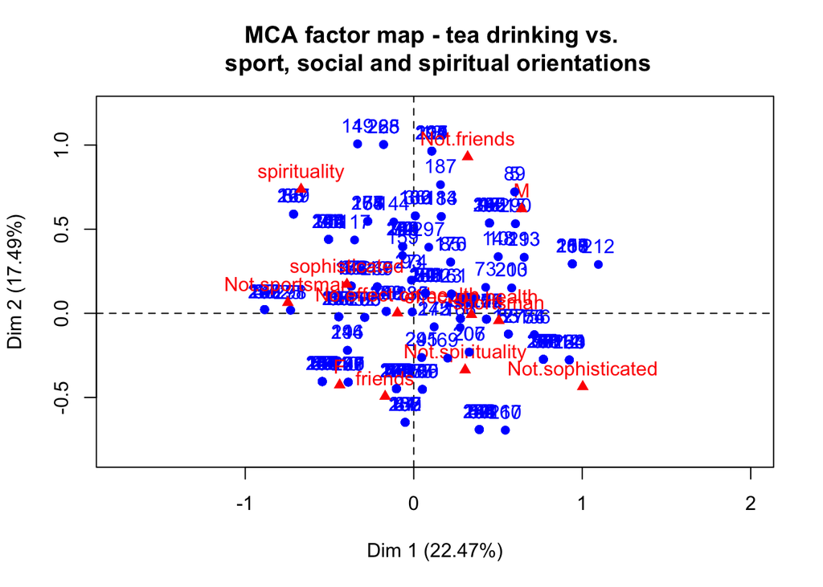

#### **3.7 Some conclusions of the MCA and it’s plot**

- There’s a clear difference in the social role of tea between females and males. Men prefer drinking tea alone more often than women and women tend to drink tea with friends more often than men.

This proportional barplot confirms that women drink tea more with friends than men do (which was also suggested by the MCA-plot above).

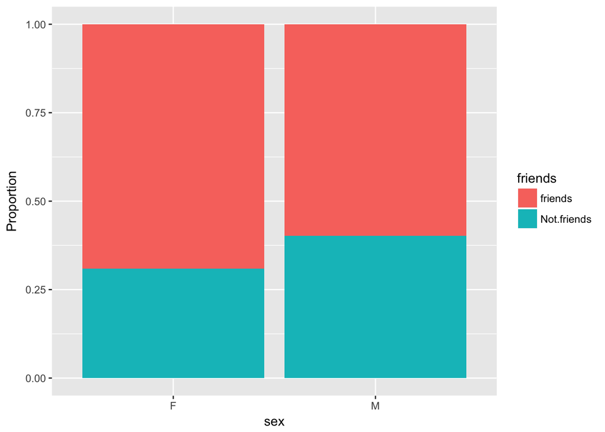

The above MCA-biplot showed that women regard tea drinking more than men as sophisticated. This finding is confirmed in the barplot below.

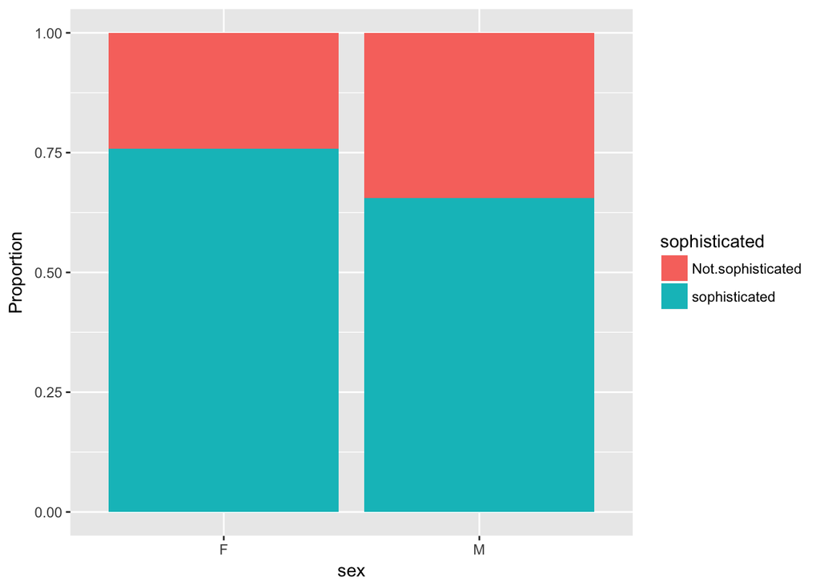